# 06_Descomposiciones_Matriciales

ana.morena

12/05/2016

### Interpretación de factores

Se procede a interpretar los factores asociados a la gráfica siguiente, conseguida a través de la descomposición matricial, a través de seis factores, de las preferencias de usuarios por géneros de las películas.

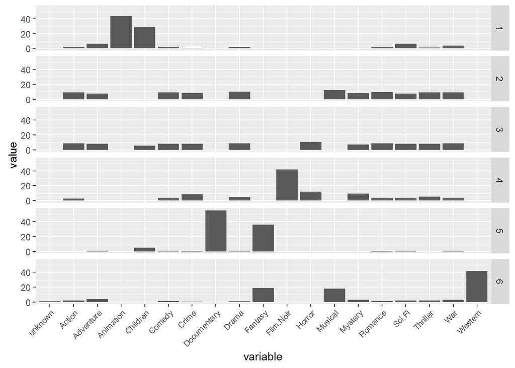

La descomposición matricial en 6 factores supone la clusterización de los clientes en 6 clusters en base a las preferencias que tienen a los géneros de las películas.

De acuerdo a esto, y de acuerdo a la gráfica obtenida (semilla 897) …

- el primer factor (cluster 1) representa a los usuarios que tienen preferencia por los géneros **Animación y Children**, es decir, por las películas (Walt Disney, Marvel, etc).
- el cuarto factor (cluster 4) representa a los usuarios que se decantan por películas de **Film.Noir**.
- el quinto factor (cluster 5) se decanta por el género **Documentary** y, en menor medida pero también de manera representativa **Fantasy**.
- el sexto factor (cluster 6) aglutina principalmente a los amantes del **Western**, aunque también les gusta los géneros **Fantasy y Musical**.
- los factores 2 y 3 representan a los usuarios que, si bien han valorado el resto de géneros, no destaca un género respecto al resto.

### Aplicación de distintos números de factores

El efecto que produce el incremento en el número de factores es la clusterización en la diferenciación en clusteres distintos de los géneros que se han comentado previamente:

- Animación
- Children
- Film.Noir
- Documentary
- Fantasy
- Musical
- Western

…e, incluso, la diferenciación de un género nuevo.

Así, por ejemplo, el fijar 7 factores significa que el género **Fantasy** pasa a destacarse en el cluster 4 y el género **Musical** en el cluster 5.

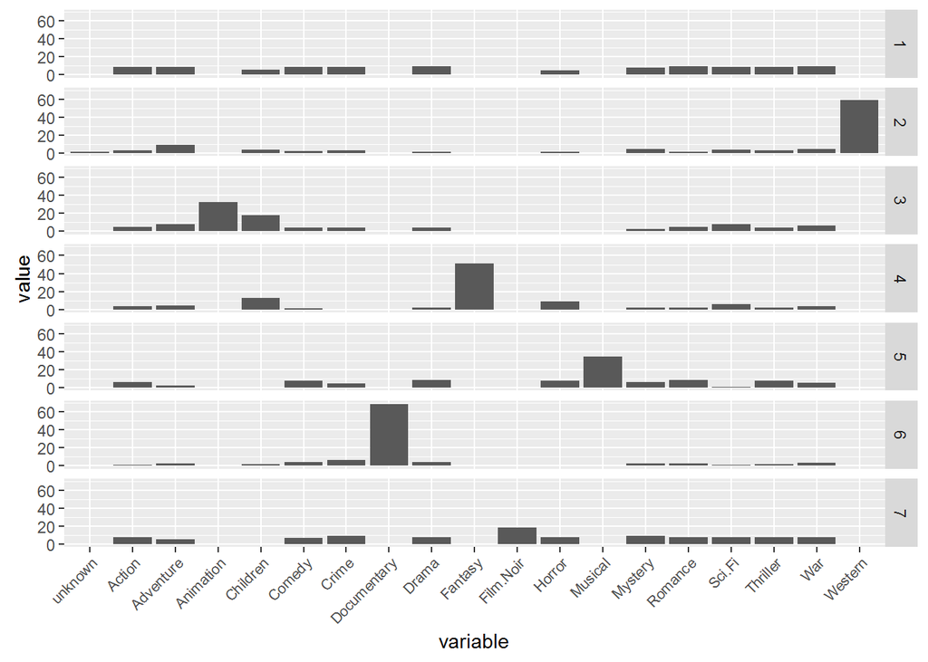

… o el fijar 9 factores significa que los géneros **Animación** y **Children** se destacan de manera independiente en 2 clusteres y empieza a resaltar el género **Horror**.

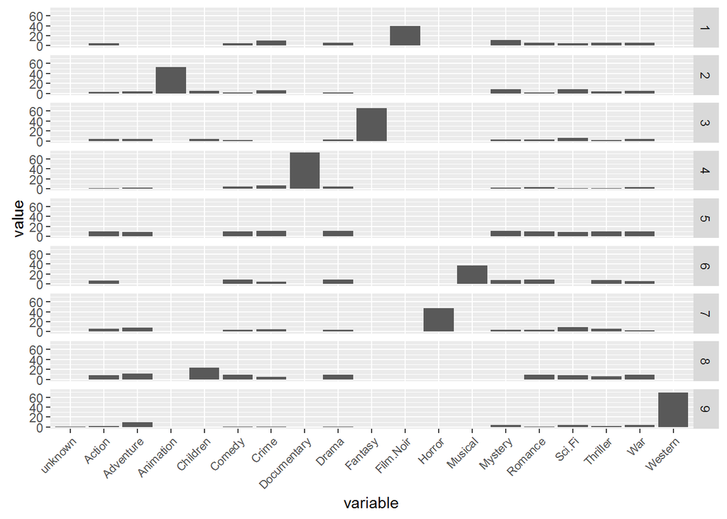